# Visualizing Earnings Based On College Majors

In this guided project, we'll explore how using the pandas plotting functionality along with the Jupyter notebook interface allows us to explore data quickly using visualizations. We'll be working with a dataset on the job outcomes of students who graduated from college between 2010 and 2012. The original data on job outcomes was released by American Community Survey, which conducts surveys and aggregates the data. FiveThirtyEight cleaned the dataset and released it on their Github repo.

Each row in the dataset represents a different major in college and contains information on gender diversity, employment rates, median salaries, and more.

Using visualizations, we can start to explore questions from the dataset like:

Do students in more popular majors make more money?

- Using scatter plots

How many majors are predominantly male? Predominantly female?

- Using histograms

Which category of majors have the most students?

- Using bar plots

```python
import pandas as pd
import matplotlib.pyplot as plt
%matplotlib inline
recent_grads = pd.read_csv('recent-grads.csv')
print(recent_grads.iloc[0]) #looking at the first row formatted as table
```

```
Rank                                        1
Major_code                               2419
Major                   PETROLEUM ENGINEERING
Total                                    2339
Men                                      2057
Women                                     282
Major_category                    Engineering
ShareWomen                           0.120564
Sample_size                                36
Employed                                 1976
Full_time                                1849
Part_time                                 270
Full_time_year_round                     1207
Unemployed                                 37
Unemployment_rate                   0.0183805
Median                                 110000
P25th                                   95000
P75th                                  125000
College_jobs                             1534
Non_college_jobs                          364
Low_wage_jobs                             193
Name: 0, dtype: object
```

```python
print(recent_grads.head())
```

```
   Rank  Major_code                                      Major    Total  \
0     1        2419                      PETROLEUM ENGINEERING   2339.0
1     2        2416             MINING AND MINERAL ENGINEERING    756.0
2     3        2415                  METALLURGICAL ENGINEERING    856.0
3     4        2417  NAVAL ARCHITECTURE AND MARINE ENGINEERING   1258.0
4     5        2405                       CHEMICAL ENGINEERING  32260.0

       Men    Women Major_category  ShareWomen  Sample_size  Employed  ...  \
0   2057.0    282.0    Engineering    0.120564           36      1976  ...
1    679.0     77.0    Engineering    0.101852            7       640  ...
2    725.0    131.0    Engineering    0.153037            3       648  ...
3   1123.0    135.0    Engineering    0.107313           16       758  ...
4  21239.0  11021.0    Engineering    0.341631          289     25694  ...

   Part_time  Full_time_year_round  Unemployed  Unemployment_rate  Median  \
0        270                  1207          37           0.018381  110000
1        170                   388          85           0.117241   75000
2        133                   340          16           0.024096   73000
3        150                   692          40           0.050125   70000
4       5180                 16697        1672           0.061098   65000

   P25th   P75th  College_jobs  Non_college_jobs  Low_wage_jobs
0  95000  125000          1534               364            193
1  55000   90000           350               257             50
2  50000  105000           456               176              0
3  43000   80000           529               102              0
4  50000   75000         18314              4440            972

[5 rows x 21 columns]
```

```python
print(recent_grads.tail())
```

```
     Rank  Major_code                   Major   Total     Men   Women  \
168   169        3609                 ZOOLOGY  8409.0  3050.0  5359.0
169   170        5201  EDUCATIONAL PSYCHOLOGY  2854.0   522.0  2332.0
170   171        5202     CLINICAL PSYCHOLOGY  2838.0   568.0  2270.0
171   172        5203   COUNSELING PSYCHOLOGY  4626.0   931.0  3695.0
172   173        3501         LIBRARY SCIENCE  1098.0   134.0   964.0

               Major_category  ShareWomen  Sample_size  Employed  ...  \
168    Biology & Life Science    0.637293           47      6259  ...
169  Psychology & Social Work    0.817099            7      2125  ...
170  Psychology & Social Work    0.799859           13      2101  ...
171  Psychology & Social Work    0.798746           21      3777  ...
172                 Education    0.877960            2       742  ...

     Part_time  Full_time_year_round  Unemployed  Unemployment_rate  Median  \
168       2190                  3602         304           0.046320   26000
169        572                  1211         148           0.065112   25000
170        648                  1293         368           0.149048   25000
171        965                  2738         214           0.053621   23400
172        237                   410          87           0.104946   22000

     P25th  P75th  College_jobs  Non_college_jobs  Low_wage_jobs
168  20000  39000          2771              2947            743
169  24000  34000          1488               615             82
170  25000  40000           986               870            622
171  19200  26000          2403              1245            308
172  20000  22000           288               338            192

[5 rows x 21 columns]
```

```python
recent_grads.describe() # summary stat of numeric columns
```

|  | Rank | Major_code | Total | Men | Women | ShareWomen | Sample_size | Employed | Full_time | Part_time | Full_time_year_round | Unemployed | Unemployment_rate | Median | P25th | P75th | College_jobs | Non_college_jobs | Low_wage_jobs |
| --- | --- | --- | --- | --- | --- | --- | --- | --- | --- | --- | --- | --- | --- | --- | --- | --- | --- | --- | --- |
| count | 173.000000 | 173.000000 | 172.000000 | 172.000000 | 172.000000 | 172.000000 | 173.000000 | 173.000000 | 173.000000 | 173.000000 | 173.000000 | 173.000000 | 173.000000 | 173.000000 | 173.000000 | 173.000000 | 173.000000 | 173.000000 | 173.000000 |
| mean | 87.000000 | 3879.815029 | 39370.081395 | 16723.406977 | 22646.674419 | 0.522223 | 356.080925 | 31192.763006 | 26029.306358 | 8832.398844 | 19694.427746 | 2416.329480 | 0.068191 | 40151.445087 | 29501.445087 | 51494.219653 | 12322.635838 | 13284.497110 | 3859.017341 |
| std | 50.084928 | 1687.753140 | 63483.491009 | 28122.433474 | 41057.330740 | 0.231205 | 618.361022 | 50675.002241 | 42869.655092 | 14648.179473 | 33160.941514 | 4112.803148 | 0.030331 | 11470.181802 | 9166.005235 | 14906.279740 | 21299.868863 | 23789.655363 | 6944.998579 |
| min | 1.000000 | 1100.000000 | 124.000000 | 119.000000 | 0.000000 | 0.000000 | 2.000000 | 0.000000 | 111.000000 | 0.000000 | 111.000000 | 0.000000 | 0.000000 | 22000.000000 | 18500.000000 | 22000.000000 | 0.000000 | 0.000000 | 0.000000 |
| 25% | 44.000000 | 2403.000000 | 4549.750000 | 2177.500000 | 1778.250000 | 0.336026 | 39.000000 | 3608.000000 | 3154.000000 | 1030.000000 | 2453.000000 | 304.000000 | 0.050306 | 33000.000000 | 24000.000000 | 42000.000000 | 1675.000000 | 1591.000000 | 340.000000 |
| 50% | 87.000000 | 3608.000000 | 15104.000000 | 5434.000000 | 8386.500000 | 0.534024 | 130.000000 | 11797.000000 | 10048.000000 | 3299.000000 | 7413.000000 | 893.000000 | 0.067961 | 36000.000000 | 27000.000000 | 47000.000000 | 4390.000000 | 4595.000000 | 1231.000000 |
| 75% | 130.000000 | 5503.000000 | 38909.750000 | 14631.000000 | 22553.750000 | 0.703299 | 338.000000 | 31433.000000 | 25147.000000 | 9948.000000 | 16891.000000 | 2393.000000 | 0.087557 | 45000.000000 | 33000.000000 | 60000.000000 | 14444.000000 | 11783.000000 | 3466.000000 |
| max | 173.000000 | 6403.000000 | 393735.000000 | 173809.000000 | 307087.000000 | 0.968954 | 4212.000000 | 307933.000000 | 251540.000000 | 115172.000000 | 199897.000000 | 28169.000000 | 0.177226 | 110000.000000 | 95000.000000 | 125000.000000 | 151643.000000 | 148395.000000 | 48207.000000 |

There are some missing values. We need to drop them to get the proper picture in numeric.

```python
# count the number of rows before we drop na values
raw_data_count = recent_grads.shape[0] # number of rows
print(raw_data_count)
```

```
173
```

```python
recent_grads = recent_grads.dropna()
```

```python
# now lets count the number of rows after dropping na values
cleaned_data_count = recent_grads.shape[0]
print(cleaned_data_count)
```

```
172
```

There wad only one row that had missing value.

## Pandas, Scatter plots

Most of the plotting functionality in pandas is contained within the DataFrame.plot() method. We use the kind parameter to specify the type of plot we want.

In this section, we will use scatter plots to answer following questions :

- Do students in more popular majors make more money?
- Do students that majored in subjects that were majority female make more money?
- Is there any link between the number of full-time employees and median salary?

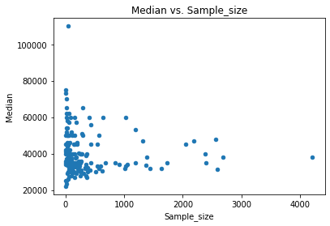

```python
ax1 = recent_grads.plot(x='Sample_size', y='Median', kind='scatter', title='Median vs. Sample_size')
```

We can say from the above scatter plot that, high median salary offered to the less popular subjects.

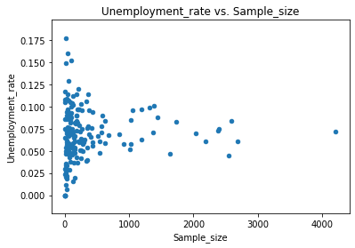

```python
ax2 = recent_grads.plot(x='Sample_size', y='Unemployment_rate', kind='scatter', title='Unemployment_rate vs. Sample_size')
```

Unemployment rate is higher among the students who persue less popular subjects.

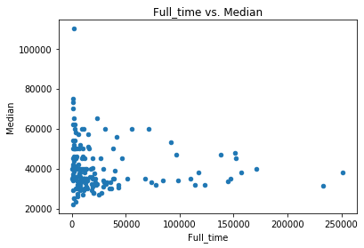

```python
ax3 = recent_grads.plot(x='Full_time', y='Median', kind='scatter', title='Full_time vs. Median')
```

There is no positive corelation between full time employment and median salary. Rather, less number of full time employees earn have higher median salary

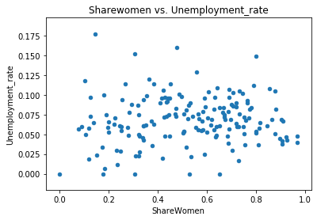

```python
ax4 = recent_grads.plot(x='ShareWomen', y='Unemployment_rate', kind='scatter', title='Sharewomen vs. Unemployment_rate')
```

There is no corelation between unemployment rate and the percentage that women have in particular job fields.

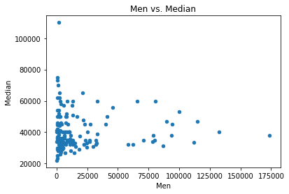

```python
ax5 = recent_grads.plot(x='Men', y='Median', kind='scatter', title='Men vs. Median')
```

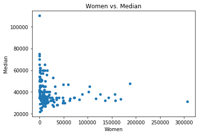

```python
ax6 = recent_grads.plot(x='Women', y='Median', kind='scatter', title='Women vs. Median')
```

We can see that there is no positive corelation between the number of men or women working in a particular job sector and median salary. But its noticeable that there are more women working than men and there is a bias towards male employees regarding higher median salary.

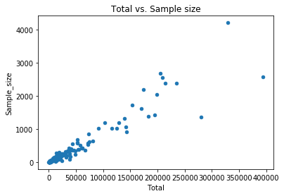

```python
# just wanted to see the relationship between the total and sample size columns
ax6 = recent_grads.plot(x='Total', y='Sample_size', kind='scatter', title='Total vs. Sample size')
```

Just wanted to make sure that the samples were collected in respect to total numbers, means they have a positive corelation.

## Pandas, histograms

We will use histograms to explore some questions like :

- What percent of majors are predominantly male? Predominantly female?
- What's the most common median salary range?

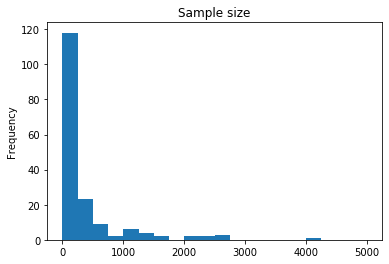

```python
recent_grads['Sample_size'].plot(kind='hist',bins = 20, range=(0,5000), title = 'Sample size')
```

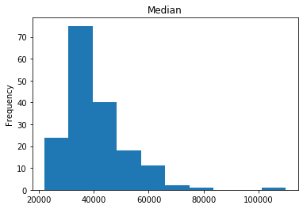

```python
recent_grads['Median'].plot(kind='hist', title = 'Median')
```

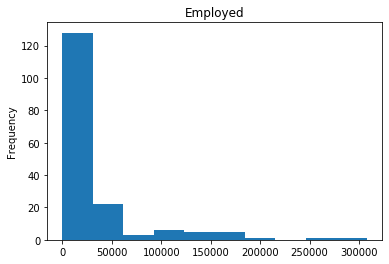

```python
recent_grads['Employed'].plot(kind='hist', title = 'Employed')
```

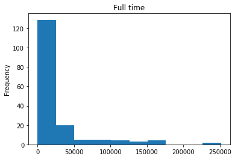

```python
recent_grads['Full_time'].plot(kind='hist', title = 'Full time')
```

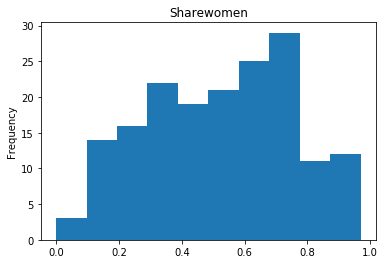

```python
recent_grads['ShareWomen'].plot(kind='hist', title = 'Sharewomen')
```

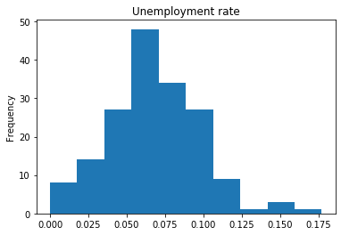

```python
recent_grads['Unemployment_rate'].plot(kind='hist', title = 'Unemployment rate')
```

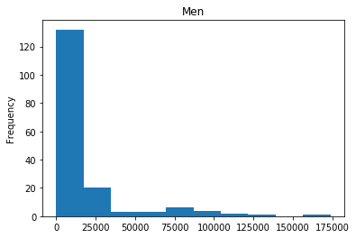

```python
recent_grads['Men'].plot(kind='hist', title = 'Men')
```

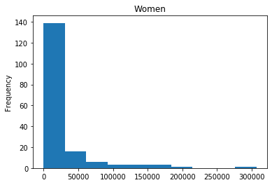

```python
recent_grads['Women'].plot(kind='hist', title = 'Women')
```

## Scatter Matrix Plot

A scatter matrix plot combines both scatter plots and histograms into one grid of plots and allows us to explore potential relationships and distributions simultaneously. A scatter matrix plot consists of n by n plots on a grid, where n is the number of columns, the plots on the diagonal are histograms, and the non-diagonal plots are scatter plots.

```
array([[<matplotlib.axes._subplots.AxesSubplot object at 0x000000000E719C08>,
      dtype=object)
```

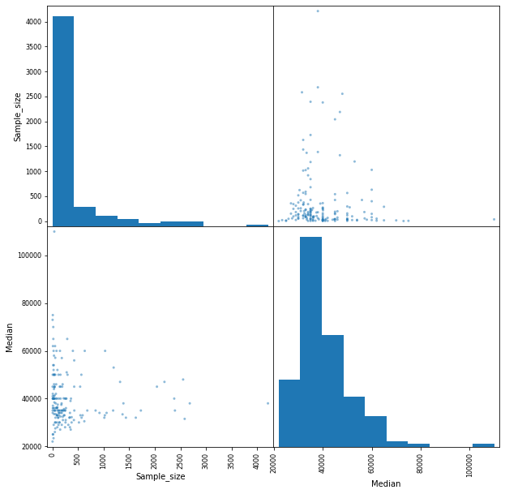

```python
from pandas.plotting import scatter_matrix

scatter_matrix(recent_grads[['Sample_size', 'Median']], figsize=(10,10))
```

```
array([[<matplotlib.axes._subplots.AxesSubplot object at 0x000000000EC14108>,
      dtype=object)
```

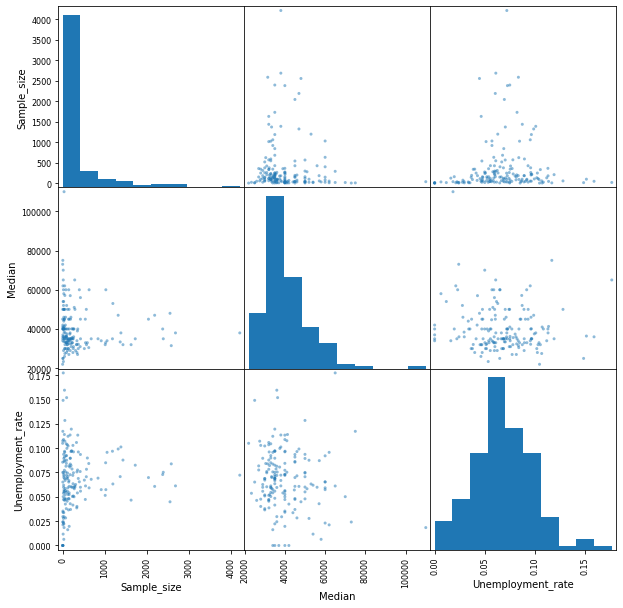

```python
scatter_matrix(recent_grads[['Sample_size', 'Median', 'Unemployment_rate']], figsize=(10,10))
```

Few observations : Median salary is much hgher among less popular subjects, however, students in less popular subjects face more unemployment. It can mean that, someone has to be really good at his work to avoid unemployment and if s/he gets employed, s/he will have the chance to earn more than others who studied popular subjects.

## Pandas, Bar plots

We will now use bar plots to ansswer following questions :

- Use bar plots to compare the percentages of women (ShareWomen) from the first ten rows and last ten rows of the recent_grads dataframe.
- Use bar plots to compare the unemployment rate (Unemployment_rate) from the first ten rows and last ten rows of the recent_grads dataframe.

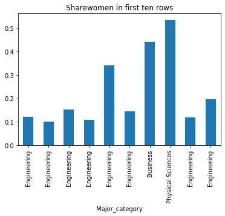

```python
recent_grads[:10].plot.bar(x='Major_category', y='ShareWomen', legend = False, title = 'Sharewomen in first ten rows')
```

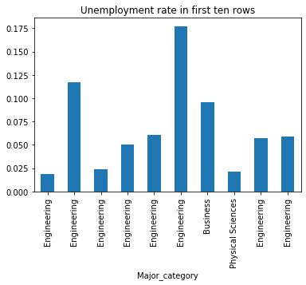

```python
recent_grads[:10].plot.bar(x='Major_category', y='Unemployment_rate', legend = False, title = 'Unemployment rate in first ten rows')
```

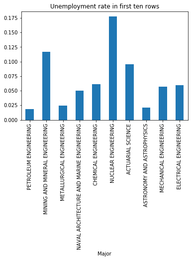

```python
recent_grads[:10].plot.bar(x='Major', y='Unemployment_rate', legend = False, title = 'Unemployment rate in first ten rows')
```

Engineering subjects like mining and mineral engineering and nuclear engineering has more unemployment rates. But as the study suggests, if anyone is really good at these subjects and they get hired, they earn much more than others.